# R Code for Portfolio Optimization Chapter 10 – Portfolios with Alternative Risk Measures

Daniel P. Palomar (2025). [Portfolio Optimization: Theory and Application.](https://portfoliooptimizationbook.com/) Cambridge University Press.

Last update: March 14, 2025

# Loading packages

The following packages are used in the examples:

```r
# basic finance
library(xts)                    # to manipulate time series of stock data
library(PerformanceAnalytics)   # to compute performance measures
library(portfolioBacktest)      # to conduct backtests
library(pob)                    # book package with financial data

# plotting
library(ggplot2)                # for nice plots
library(reshape2)               # to reshape data
library(patchwork)              # for combining plots
library(latex2exp)              # for latex symbols with TeX()

# optimization
library(CVXR)
library(nloptr)
library(alabama)
```

# Downside risk portfolios

First, let’s define the downside risk portfolio (as well as the two benchmarks MVP and GMVP):

```r
library(CVXR)

design_MVP <- function(mu, Sigma, lambda = 1, ub = Inf) {
  w <- Variable(nrow(Sigma))
  prob <- Problem(Maximize(t(mu) %*% w - (lambda/2)*quad_form(w, Sigma)),
                  constraints = list(w >= 0, sum(w) == 1, w <= ub))
  result <- solve(prob)
  w <- as.vector(result$getValue(w))
  return(w)
}

design_GMVP <- function(Sigma) design_MVP(mu = rep(0, ncol(Sigma)), Sigma = Sigma)

design_DRportfolio <- function(X, alpha = 2, lmd = Inf, tau = c("mu", "zero")) {
  X <- as.matrix(X)
  N <- ncol(X)

  # disaster level
  tau <- match.arg(tau)
  if (tau == "zero")
    mu <- rep(0, N)
  else
    mu <- colMeans(X)

  # design
  w <- Variable(N)
  if (lmd == Inf)
    prob <- Problem(Minimize(mean(pos(t(mu) %*% w - X %*% w)^alpha)),
                    constraints = list(w >= 0, sum(w) == 1))
  else
    prob <- Problem(Maximize(t(w) %*% mu - lmd * mean(pos(t(mu) %*% w - X %*% w)^alpha)),
                    constraints = list(w >= 0, sum(w) == 1))

  if (alpha == 1)
    result <- solve(prob, solver = "GLPK")  #installed_solvers()
  else
    result <- solve(prob)
  if (!result$status %in% c("optimal", "optimal_inaccurate"))
    browser()
  return(as.vector(result$getValue(w)))
}
```

Then, prepare all the portfolio instances for the backtest:

```r
EWP <- function(data, ...) {
  N <- ncol(data[[1]])
  return(rep(1/N, N))
}

GMVP <- function(dataset, ...) {
  X <- diff(log(dataset$prices))[-1]
  Sigma <- cov(X)
  design_GMVP(Sigma)
}

MVP <- function(dataset, ...) {
  X <- diff(log(dataset$prices))[-1]
  Sigma <- cov(X)
  mu <- colMeans(X)
  design_MVP(mu, Sigma, lambda = 100)
}

DR_alpha1 <- function(dataset, ...) {
  X <- diff(log(dataset$prices))[-1]
  design_DRportfolio(X, alpha = 1, tau = "zero")
}

DR_alpha2 <- function(dataset, ...) {
  X <- diff(log(dataset$prices))[-1]
  design_DRportfolio(X, alpha = 2, tau = "zero")
}

DR_alpha2_approx <- function(dataset, ...) {
  X <- diff(log(dataset$prices))[-1]
  tau <- 0
  Xpos <- pmax(tau - X, 0)
  Sigma <- cov(Xpos)
  design_GMVP(Sigma)
}

DR_alpha3 <- function(dataset, ...) {
  X <- diff(log(dataset$prices))[-1]
  design_DRportfolio(X, alpha = 3, tau = "zero")
}
```

## Single backtest

Portfolio allocation of different downside risk portfolios:

```r
library(pob)
stock_prices <- SP500_2015to2020$stocks["2019::",
                                        c("AAPL", "AMZN", "AMD", "GM", "GOOGL", "MGM", "MSFT", "QCOM", "TSCO", "UPS")]

# backtest
bt <- portfolioBacktest(list("GMVP"                            = GMVP,
                             "Min. downside risk (alpha = 1)"  = DR_alpha1,
                             "Min. semivariance"               = DR_alpha2,
                             "Min. semivariance (approx)"      = DR_alpha2_approx,
                             "Min. downside risk (alpha = 3)"  = DR_alpha3),
                        list(list("prices" = stock_prices)),
                        lookback = 12*21, optimize_every = 21, rebalance_every = 1)
```

```
Backtesting 5 portfolios over 1 datasets (periodicity = daily data)...
```

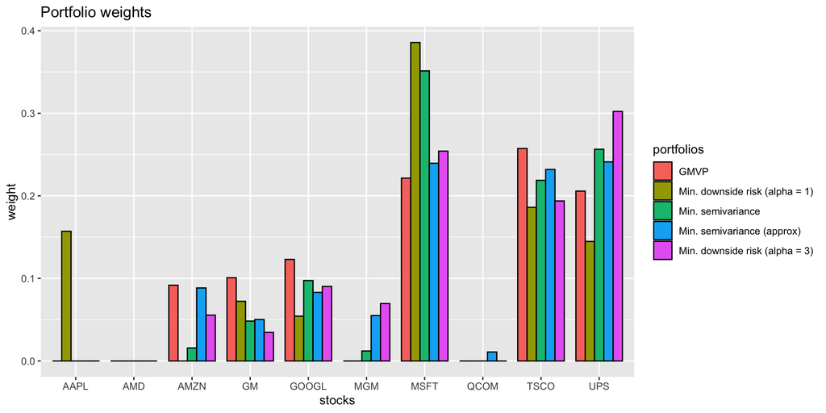

```r
listPortfoliosWithFailures(bt)

data.frame(
  "stocks" = names(stock_prices),
  "GMVP"   = as.numeric(bt$`GMVP`$data1$w_optimized[1, ]),
  "Min. downside risk (alpha = 1)" = as.numeric(bt$`Min. downside risk (alpha = 1)`$data1$w_optimized[1, ]),
  "Min. semivariance"              = as.numeric(bt$`Min. semivariance`$data1$w_optimized[1, ]),
  "Min. semivariance (approx)"     = as.numeric(bt$`Min. semivariance (approx)`$data1$w_optimized[1, ]),
  "Min. downside risk (alpha = 3)" = as.numeric(bt$`Min. downside risk (alpha = 3)`$data1$w_optimized[1, ]),
  check.names = FALSE) |>
  melt(id.vars = "stocks") |>
  ggplot(aes(x = stocks, y = value, fill = variable)) +
  geom_bar(stat = "identity", position = "dodge", color = "black", width = 0.8) +
  labs(fill = "portfolios") +
  ylab("weight") +
  ggtitle("Portfolio weights")
```

```r
bt_summary_median <- backtestSummary(bt)
summaryTable(bt_summary_median, type = "kable",
             measures = c("Sharpe ratio", "Sortino ratio", "annual return", "annual volatility", "downside deviation", "CVaR", "max drawdown"))
```

Performance table

| Portfolio | Sharpe ratio | Sortino ratio | annual return | annual volatility | downside deviation | max drawdown |
| --- | --- | --- | --- | --- | --- | --- |
| GMVP | 1.70 | 2.44 | 61% | 36% | 0.25 | 27% |
| Min. downside risk (alpha = 1) | 1.73 | 2.51 | 66% | 38% | 0.26 | 26% |
| Min. semivariance | 1.78 | 2.58 | 67% | 38% | 0.26 | 27% |
| Min. semivariance (approx) | 1.75 | 2.51 | 64% | 37% | 0.25 | 27% |
| Min. downside risk (alpha = 3) | 1.78 | 2.60 | 67% | 37% | 0.26 | 27% |

Backtest performance of different downside risk portfolios:

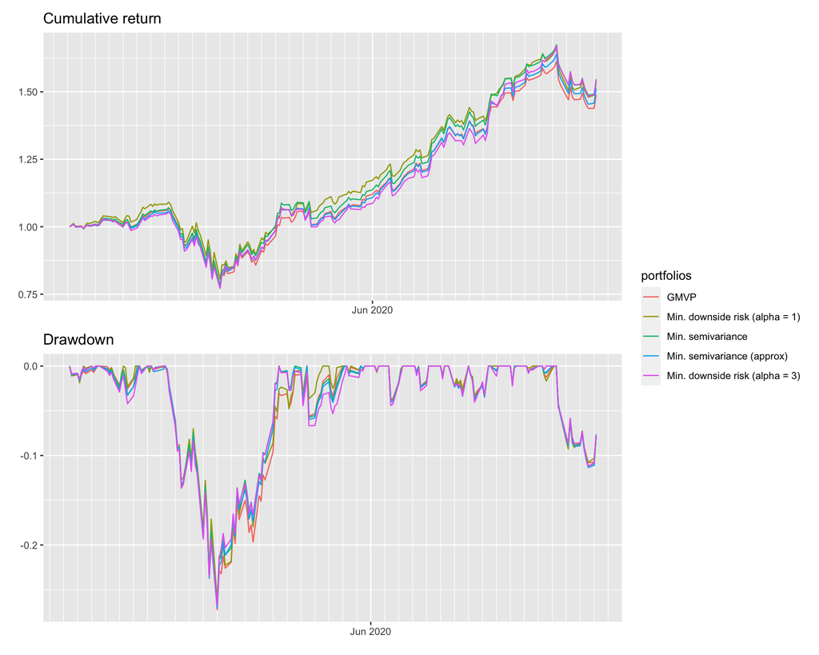

```r
p1 <- backtestChartCumReturn(bt) +
  scale_x_date(date_breaks = "6 months", date_labels = "%b %Y", date_minor_breaks = "1 week") +
  theme(legend.title = element_text()) + labs(color = "portfolios", linetype = "portfolios") +
  ggtitle("Cumulative return")

p2 <- backtestChartDrawdown(bt) +
  scale_x_date(date_breaks = "6 months", date_labels = "%b %Y", date_minor_breaks = "1 week") +
  theme(legend.title = element_text()) + labs(color = "portfolios", linetype = "portfolios") +
  ggtitle("Drawdown")

p1 / p2 + plot_layout(guides = "collect")
```

## Multiple backtests

Backtest performance of different downside risk portfolios ($N=50$) over 50 datasets:

```r
library(pob)

# resample data
set.seed(42)
stock_prices_resampled <- financialDataResample(list("prices" = SP500_2015to2020$stocks),
                                                num_datasets = 50, N_sample = 50, T_sample = 252*2)
```

```
50 datasets resampled (with N = 50 instruments and length T = 504) from the original data between 2015-01-05 and 2020-09-22.
```

```r
# perform multiple backtest on the resampled data
bt <- portfolioBacktest(list("GMVP"                            = GMVP,
                             "Min. downside risk (alpha = 1)"  = DR_alpha1,
                             "Min. semivariance"               = DR_alpha2,
                             "Min. semivariance (approx)"      = DR_alpha2_approx,
                             "Min. downside risk (alpha = 3)"  = DR_alpha3),
                        dataset_list = stock_prices_resampled,
                        lookback = 12*21, optimize_every = 21, rebalance_every = 1,
                        paral_datasets = 6, show_progress_bar = TRUE)
```

```
Backtesting 5 portfolios over 50 datasets (periodicity = daily data)...
```

```
  Backtesting function "GMVP           " (1/5)
```

```
  Backtesting function "Min. downside risk (alpha = 1)" (2/5)
```

```
  Backtesting function "Min. semivariance" (3/5)
```

```
  Backtesting function "Min. semivariance (approx)" (4/5)
```

```
  Backtesting function "Min. downside risk (alpha = 3)" (5/5)
```

```r
listPortfoliosWithFailures(bt)

bt_summary_median <- backtestSummary(bt)
summaryTable(bt_summary_median, type = "kable", measures = c("Sharpe ratio", "CVaR", "max drawdown", "cpu time"))
```

Performance table

| Portfolio | Sharpe ratio | max drawdown | cpu time |
| --- | --- | --- | --- |
| GMVP | 1.38 | 9% | 0.17 |
| Min. downside risk (alpha = 1) | 1.45 | 9% | 0.19 |
| Min. semivariance | 1.43 | 9% | 0.16 |
| Min. semivariance (approx) | 1.48 | 9% | 0.18 |
| Min. downside risk (alpha = 3) | 1.43 | 9% | 0.27 |

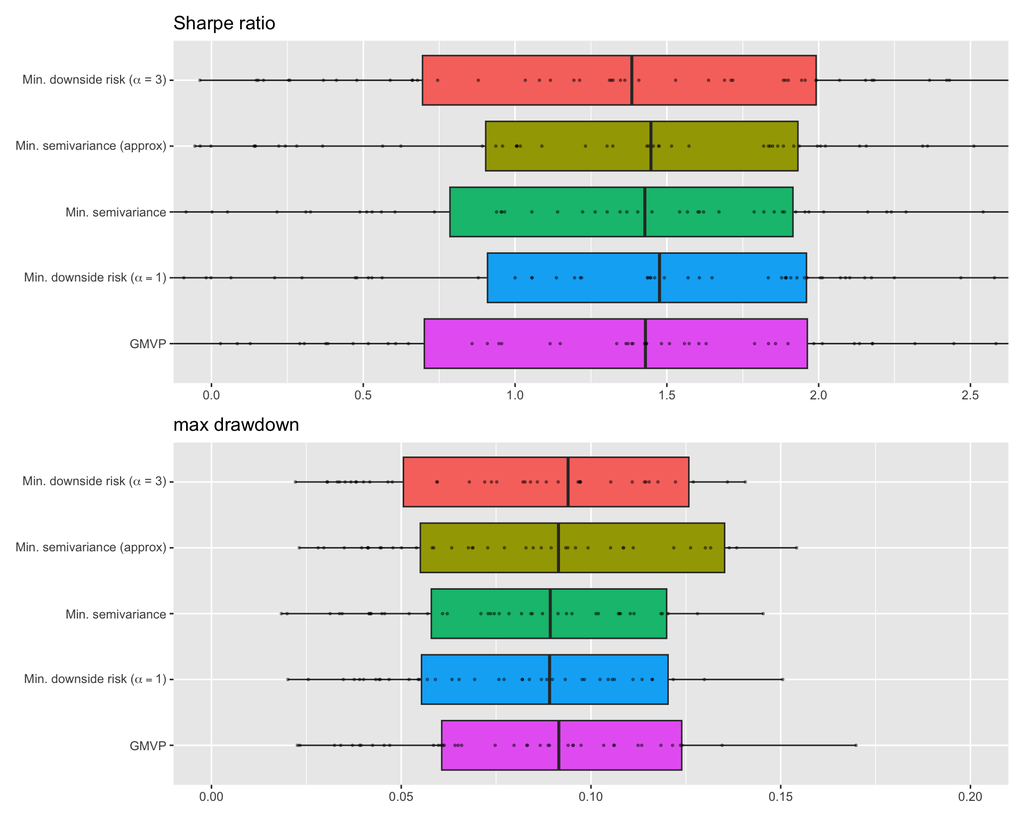

```r
p1 <- backtestBoxPlot(bt, "Sharpe ratio") + coord_flip(ylim = c(0, 2.5)) +
  scale_x_discrete(labels = c("GMVP", TeX("Min. downside risk ($\\alpha = 1$)"), "Min. semivariance",
                               "Min. semivariance (approx)", TeX("Min. downside risk ($\\alpha$ = 3)")),
                   limits = rev(names(bt)))
p2 <- backtestBoxPlot(bt, "max drawdown") + coord_flip(ylim = c(0, 0.2)) +
  scale_x_discrete(labels = c("GMVP", TeX("Min. downside risk ($\\alpha = 1$)"), "Min. semivariance",
                               "Min. semivariance (approx)", TeX("Min. downside risk ($\\alpha$ = 3)")),
                   limits = rev(names(bt)))

p1 / p2
```

# Tail portfolios

First, let’s define the worst-case portfolio, the CVaR portfolio, and the EVaR portfolio:

```r
library(CVXR)
library(nloptr)
library(alabama)

portolioWorstCase <- function(X, lmd = 5) {
  T <- nrow(X)
  N <- ncol(X)
  X <- as.matrix(X)
  mu <- colMeans(X)

  # design (https://cvxr.rbind.io/cvxr_functions/)
  w <- Variable(N)
  prob <- Problem(Maximize(t(w) %*% mu - lmd * max_entries(- X %*% w)),
                    constraints = list(w >= 0, sum(w) == 1))
  result <- solve(prob, solver = "GLPK")  #installed_solvers()
  return(as.vector(result$getValue(w)))
}

portolioCVaR <- function(X, lmd = 5, alpha = 0.95) {
  T <- nrow(X)
  N <- ncol(X)
  X <- as.matrix(X)
  mu <- colMeans(X)

  w <- Variable(N)
  tau <- Variable(1)
  u <- Variable(T)
  prob <- Problem(Maximize( t(w) %*% mu - lmd*(tau + mean(u)/(1-alpha)) ),
                  constraints = list(u >= 0, u >= -X %*% w - tau,
                                       w >= 0, sum(w) == 1))
  tryCatch(result <- solve(prob, solver = "GLPK"),         #installed_solvers()
           error = function(e) geterrmessage())

  return(as.vector(result$getValue(w)))
}
#w <- CVaR_alpha95(stock_prices_resampled$`dataset 1`)

portolioEVaR_CVXR <- function(X, lmd = 1000, alpha = 0.95) {
  T <- nrow(X)
  N <- ncol(X)
  X <- as.matrix(X)
  mu <- colMeans(X)

  # CVXR
  w <- Variable(N)
  s <- Variable(1)
  t <- Variable(1)
  u <- Variable(T)

  prob <- Problem(Maximize( t(w) %*% mu - lmd*( s - t*log((1-alpha)*T) ) ),
                  constraints = list(CVXR:::ExpCone(- X %*% w - s, t*rep(1,T), u),
                                     t >= sum(u),
                                     w >= 0, sum(w) == 1))

  result <- solve(prob, num_iter = 200, verbose = FALSE)

  return(as.vector(result$getValue(w)))
}


# https://docs.mosek.com/modeling-cookbook/expo.html
portolioEVaR_nloptr <- function(X, lmd = Inf, alpha = 0.95) {
  T <- nrow(X)
  N <- ncol(X)
  X <- as.matrix(X)
  mu <- colMeans(X)

  #
  # via general solver nloptr
  #
  w0   <- rep(1/N, N)
  t0 <- 1

  fn_min <- function(x) {
    w <- x[1:N]
    t <- x[N+1]
    -( t(w) %*% mu - lmd*t*log(mean(exp(- X %*% (w/t)))/(1-alpha)) )
  }
  h_eq <- function(x) {
    w <- x[1:N]
    t <- x[N+1]
    sum(w) - 1
  }
  h_eq_jac <- function(x) {
    w <- x[1:N]
    t <- x[N+1]
    rbind(c(rep(1, N), 0))
  }

  res <- nloptr::slsqp(x0 = c(w0, t0),
                       fn = fn_min, # gr =
                       lower = rep(0, N + 1),
                       heq = h_eq,  heqjac = h_eq_jac,
                       control = list(xtol_rel = 1e-6))  # check_derivatives = TRUE
  w_nloptr <- res$par[1:N]
  t_nloptr <- res$par[N+1]

  return(w_nloptr)
}
```

Then, prepare all the portfolio instances for the backtest:

```r
CVaR_alpha90 <- function(dataset, ...) {
  X <- diff(log(dataset$prices))[-1]
  portolioCVaR(X, lmd = 10000, alpha = 0.90)
}
CVaR_alpha95 <- function(dataset, ...) {
  X <- diff(log(dataset$prices))[-1]
  portolioCVaR(X, lmd = 10000, alpha = 0.95)
}
CVaR_alpha99 <- function(dataset, ...) {
  X <- diff(log(dataset$prices))[-1]
  portolioCVaR(X, lmd = 10000, alpha = 0.99)
}

EVaR_alpha90 <- function(dataset, ...) {
  X <- diff(log(dataset$prices))[-1]
  portolioEVaR_nloptr(X, lmd = 10000, alpha = 0.90)
}
EVaR_alpha95 <- function(dataset, ...) {
  X <- diff(log(dataset$prices))[-1]
  portolioEVaR_nloptr(X, lmd = 10000, alpha = 0.95)
}
EVaR_alpha99 <- function(dataset, ...) {
  X <- diff(log(dataset$prices))[-1]
  portolioEVaR_nloptr(X, lmd = 10000, alpha = 0.99)
}

WorstCase <- function(dataset, ...) {
  X <- diff(log(dataset$prices))[-1]
  portolioWorstCase(X, lmd = 10000)
}
```

## Single backtest

Portfolio allocation of different tail portfolios:

```r
library(pob)
stock_prices <- SP500_2015to2020$stocks["2019::",
                                        c("AAPL", "AMZN", "AMD", "GM", "GOOGL", "MGM", "MSFT", "QCOM", "TSCO", "UPS")]

# backtest
bt <- portfolioBacktest(list("GMVP"            = GMVP,
                             "Min. CVaR 90%"   = CVaR_alpha90,
                             "Min. EVaR 90%"   = EVaR_alpha90,
                             "Min. Worst-Case" = WorstCase),
                        list(list("prices" = stock_prices)),
                        lookback = 12*21, optimize_every = 21, rebalance_every = 1)
```

```
Backtesting 4 portfolios over 1 datasets (periodicity = daily data)...
```

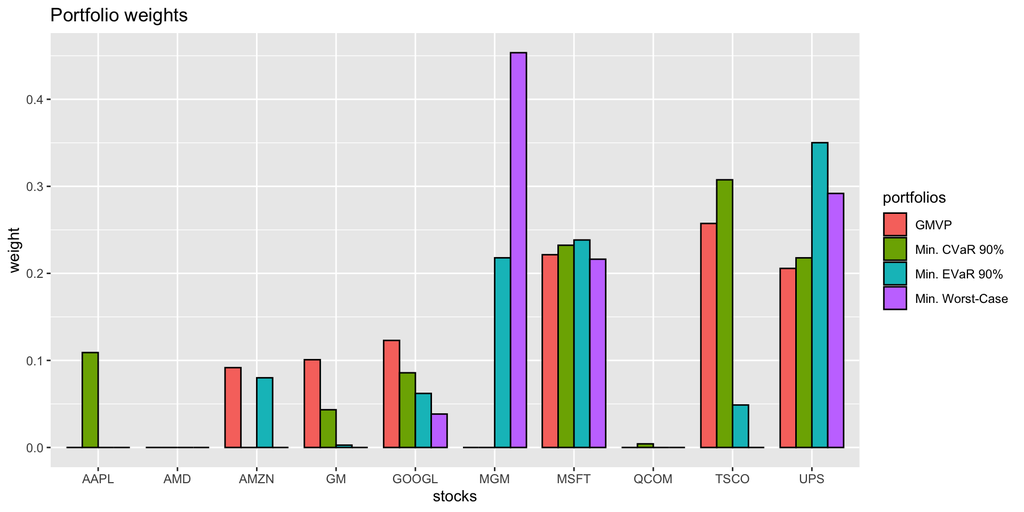

```r
listPortfoliosWithFailures(bt)

data.frame(
  "stocks" = names(stock_prices),
  "GMVP"   = as.numeric(bt$`GMVP`$data1$w_optimized[1, ]),
  "Min. CVaR 90%"   = as.numeric(bt$`Min. CVaR 90%`$data1$w_optimized[1, ]),
  "Min. EVaR 90%"   = as.numeric(bt$`Min. EVaR 90%`$data1$w_optimized[1, ]),
  "Min. Worst-Case" = as.numeric(bt$`Min. Worst-Case`$data1$w_optimized[1, ]),
  check.names = FALSE) |>
  melt(id.vars = "stocks") |>
  ggplot(aes(x = stocks, y = value, fill = variable)) +
  geom_bar(stat = "identity", position = "dodge", color = "black", width = 0.8) +
  labs(fill = "portfolios") +
  ylab("weight") +
  ggtitle("Portfolio weights")
```

```r
bt_summary_median <- backtestSummary(bt)
summaryTable(bt_summary_median, type = "kable",
             measures = c("Sharpe ratio", "Sortino ratio", "annual return", "annual volatility", "downside deviation", "CVaR", "max drawdown"))
```

Performance table

| Portfolio | Sharpe ratio | Sortino ratio | annual return | annual volatility | downside deviation | max drawdown |
| --- | --- | --- | --- | --- | --- | --- |
| GMVP | 1.70 | 2.44 | 61% | 36% | 0.25 | 27% |
| Min. CVaR 90% | 1.59 | 2.28 | 59% | 37% | 0.26 | 28% |
| Min. EVaR 90% | 1.57 | 2.27 | 59% | 38% | 0.26 | 28% |
| Min. Worst-Case | 1.24 | 1.79 | 48% | 38% | 0.27 | 33% |

Backtest performance of different tail portfolios:

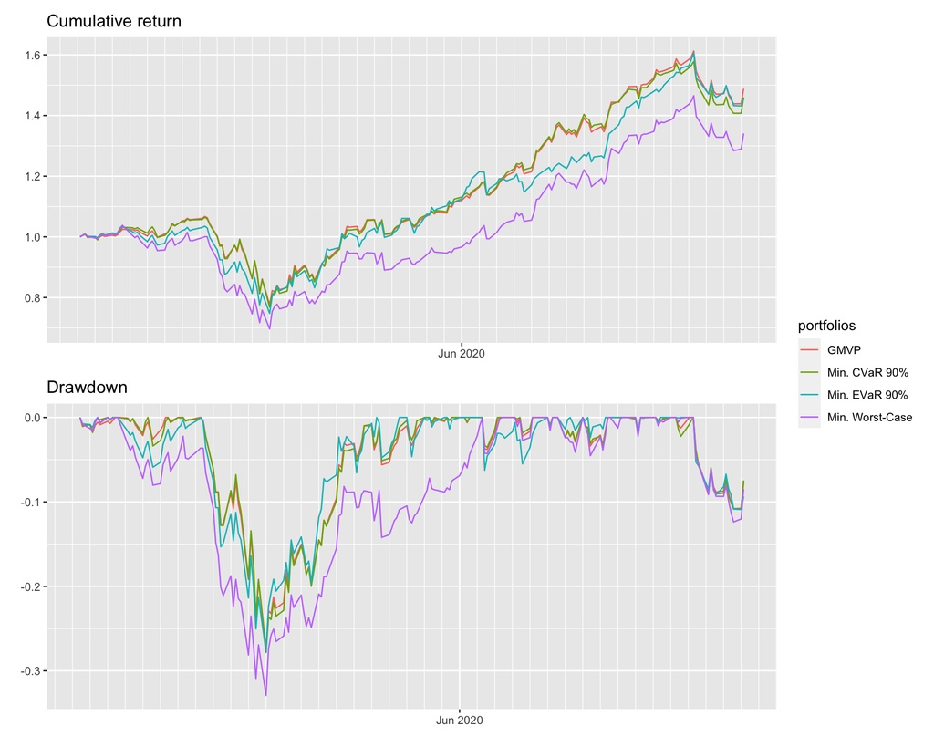

```r
p1 <- backtestChartCumReturn(bt) +
  scale_x_date(date_breaks = "6 months", date_labels = "%b %Y", date_minor_breaks = "1 week") +
  theme(legend.title = element_text()) + labs(color = "portfolios", linetype = "portfolios") +
  ggtitle("Cumulative return")

p2 <- backtestChartDrawdown(bt) +
  scale_x_date(date_breaks = "6 months", date_labels = "%b %Y", date_minor_breaks = "1 week") +
  theme(legend.title = element_text()) + labs(color = "portfolios", linetype = "portfolios") +
  ggtitle("Drawdown")

p1 / p2 + plot_layout(guides = "collect")
```

## Multiple backtests

Backtest performance of CVaR and EVaR portfolios ($N=10$) over 50 datasets:

```r
library(pob)

# resample data
set.seed(42)
stock_prices_resampled <- financialDataResample(list("prices" = SP500_2015to2020$stocks),
                                                num_datasets = 50, N_sample = 10, T_sample = 252*2)
```

```
50 datasets resampled (with N = 10 instruments and length T = 504) from the original data between 2015-01-05 and 2020-09-22.
```

```r
# perform multiple backtest on the resampled data
bt <- portfolioBacktest(list("GMVP"            = GMVP,
                             "Min. CVaR 90%"   = CVaR_alpha90,
                             "Min. EVaR 90%"   = EVaR_alpha90,
                             "Min. CVaR 95%"   = CVaR_alpha95,
                             "Min. EVaR 95%"   = EVaR_alpha95,
                             "Min. CVaR 99%"   = CVaR_alpha99,
                             "Min. EVaR 99%"   = EVaR_alpha99,
                             "Min. Worst-Case" = WorstCase),
                        dataset_list = stock_prices_resampled,
                        lookback = 12*21, optimize_every = 21, rebalance_every = 1,
                        paral_datasets = 6, show_progress_bar = TRUE)
```

```
Backtesting 8 portfolios over 50 datasets (periodicity = daily data)...
```

```
  Backtesting function "GMVP           " (1/8)
```

```
  Backtesting function "Min. CVaR 90%  " (2/8)
```

```
  Backtesting function "Min. EVaR 90%  " (3/8)
```

```
  Backtesting function "Min. CVaR 95%  " (4/8)
```

```
  Backtesting function "Min. EVaR 95%  " (5/8)
```

```
  Backtesting function "Min. CVaR 99%  " (6/8)
```

```
  Backtesting function "Min. EVaR 99%  " (7/8)
```

```
  Backtesting function "Min. Worst-Case" (8/8)
```

```r
listPortfoliosWithFailures(bt)

bt_summary_median <- backtestSummary(bt)
summaryTable(bt_summary_median, type = "kable", measures = c("Sharpe ratio", "CVaR", "max drawdown", "cpu time"))
```

Performance table

| Portfolio | Sharpe ratio | max drawdown | cpu time |
| --- | --- | --- | --- |
| GMVP | 0.99 | 12% | 0.14 |
| Min. CVaR 90% | 0.92 | 11% | 0.17 |
| Min. EVaR 90% | 1.00 | 13% | 0.03 |
| Min. CVaR 95% | 1.02 | 11% | 0.17 |
| Min. EVaR 95% | 1.03 | 13% | 0.03 |
| Min. CVaR 99% | 0.95 | 12% | 0.17 |
| Min. EVaR 99% | 0.91 | 13% | 0.35 |
| Min. Worst-Case | 1.01 | 12% | 0.13 |

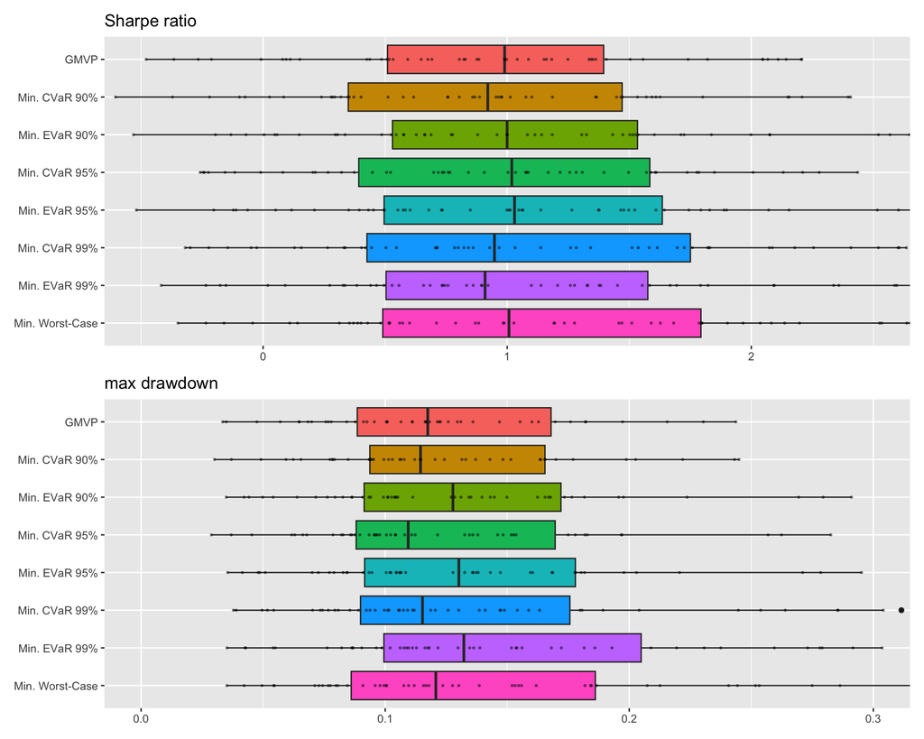

```r
p1 <- backtestBoxPlot(bt, "Sharpe ratio") + coord_flip(ylim = c(-0.5, 2.5))
p2 <- backtestBoxPlot(bt, "max drawdown") + coord_flip(ylim = c(0, 0.3))
p1 / p2
```

# Drawdown portfolios

First, let’s define the max-drawdown portfolio, ave-drawdown portfolio, and CVaR-drawdown portfolio:

```r
library(CVXR)

portfolioMaxDD <- function(X, lmd = 5) {
  T <- nrow(X)
  N <- ncol(X)
  X <- as.matrix(X)
  X_cum <- apply(X, MARGIN = 2, FUN = cumsum)
  mu <- colMeans(X)

  # variables
  w <- Variable(N)
  s <- Variable(1)
  u <- Variable(T)
  # problem
  prob <- Problem(Maximize(t(w) %*% mu - lmd*s),
                  constraints = list(w >= 0, sum(w) == 1,
                                     u <= X_cum %*% w + s,
                                     u >= X_cum %*% w,
                                     u[-1] >= u[-T]))
  result <- solve(prob, solver = "GLPK")  #installed_solvers()
  return(as.vector(result$getValue(w)))
}

portfolioAveDD <- function(X, lmd = 5) {
  T <- nrow(X)
  N <- ncol(X)
  X <- as.matrix(X)
  X_cum <- apply(X, MARGIN = 2, FUN = cumsum)
  mu <- colMeans(X)

  # variables
  w <- Variable(N)
  s <- Variable(1)
  u <- Variable(T)
  # problem
  prob <- Problem(Maximize(t(w) %*% mu- lmd*s),
                  constraints = list(w >= 0, sum(w) == 1,
                                     mean(u) <= mean(X_cum %*% w) + s,
                                     u >= X_cum %*% w,
                                     u[-1] >= u[-T]))
  result <- solve(prob, solver = "GLPK")  #installed_solvers()
  return(as.vector(result$getValue(w)))
}
#w <- portfolioAveDD(X = diff(log(stock_prices_resampled$`dataset 1`$prices))[-1])


portfolioCVaRDD <- function(X, lmd = 5, alpha = 0.95) {
  T <- nrow(X)
  N <- ncol(X)
  X <- as.matrix(X)
  X_cum <- apply(X, MARGIN = 2, FUN = cumsum)
  mu <- colMeans(X)

  # variables
  w <- Variable(N)
  tau <- Variable(1)
  s <- Variable(1)
  z <- Variable(T)
  u <- Variable(T)
  # problem
  prob <- Problem(Maximize(t(w) %*% mu - lmd*s),
                  constraints = list(w >= 0, sum(w) == 1,
                                     s >= tau + mean(z)/(1-alpha),
                                     z >= 0, z >= u - X_cum %*% w - tau,
                                     u >= X_cum %*% w,
                                     u[-1] >= u[-T]))
  result <- solve(prob, solver = "GLPK")  #installed_solvers()
  return(as.vector(result$getValue(w)))
}
```

Then, prepare all the portfolio instances for the backtest:

```r
MaxDD <- function(dataset, ...) {
  X <- diff(log(dataset$prices))[-1]
  portfolioMaxDD(X, lmd = 1000)
}

AveDD <- function(dataset, ...) {
  X <- diff(log(dataset$prices))[-1]
  portfolioAveDD(X, lmd = 1000)
}


CVaRDD_alpha90 <- function(dataset, ...) {
  X <- diff(log(dataset$prices))[-1]
  portfolioCVaRDD(X, lmd = 1000, alpha = 0.90)
}

CVaRDD_alpha95 <- function(dataset, ...) {
  X <- diff(log(dataset$prices))[-1]
  portfolioCVaRDD(X, lmd = 1000, alpha = 0.95)
}

CVaRDD_alpha99 <- function(dataset, ...) {
  X <- diff(log(dataset$prices))[-1]
  portfolioCVaRDD(X, lmd = 1000, alpha = 0.99)
}
```

## Single backtest

Portfolio allocation of different drawdown portfolios:

```r
library(pob)
stock_prices <- SP500_2015to2020$stocks["2019::",
                                        c("AAPL", "AMZN", "AMD", "GM", "GOOGL", "MGM", "MSFT", "QCOM", "TSCO", "UPS")]

# backtest
bt <- portfolioBacktest(list("GMVP"             = GMVP,
                             "Min. Max-DD"      = MaxDD,
                             "Min. Ave-DD"      = AveDD,
                             "Min. CVaR-DD 90%" = CVaRDD_alpha90),
                        list(list("prices" = stock_prices)),
                        lookback = 12*21, optimize_every = 21, rebalance_every = 1)
```

```
Backtesting 4 portfolios over 1 datasets (periodicity = daily data)...
```

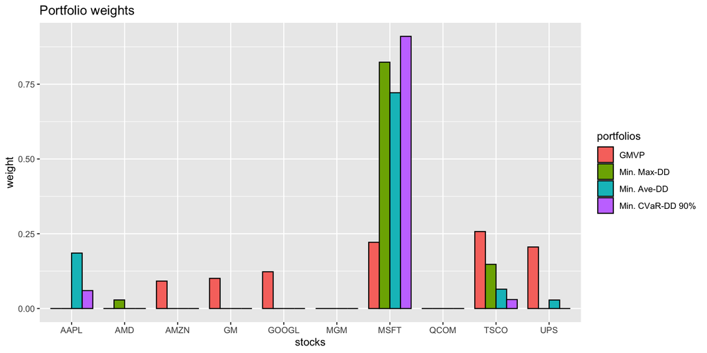

```r
listPortfoliosWithFailures(bt)

data.frame(
  "stocks" = names(stock_prices),
  "GMVP"               = as.numeric(bt$`GMVP`$data1$w_optimized[1, ]),
  "Min. Max-DD"        = as.numeric(bt$`Min. Max-DD`$data1$w_optimized[1, ]),
  "Min. Ave-DD"        = as.numeric(bt$`Min. Ave-DD`$data1$w_optimized[1, ]),
  "Min. CVaR-DD 90%"   = as.numeric(bt$`Min. CVaR-DD 90%`$data1$w_optimized[1, ]),
  check.names = FALSE) |>
  melt(id.vars = "stocks") |>
  ggplot(aes(x = stocks, y = value, fill = variable)) +
  geom_bar(stat = "identity", position = "dodge", color = "black", width = 0.8) +
  labs(fill = "portfolios") +
  ylab("weight") +
  ggtitle("Portfolio weights")
```

```r
bt_summary_median <- backtestSummary(bt)
summaryTable(bt_summary_median, type = "kable",
             measures = c("Sharpe ratio", "Sortino ratio", "annual return", "annual volatility", "downside deviation", "CVaR", "max drawdown"))
```

Performance table

| Portfolio | Sharpe ratio | Sortino ratio | annual return | annual volatility | downside deviation | max drawdown |
| --- | --- | --- | --- | --- | --- | --- |
| GMVP | 1.70 | 2.44 | 61% | 36% | 0.25 | 27% |
| Min. Max-DD | 1.81 | 2.55 | 73% | 41% | 0.29 | 32% |
| Min. Ave-DD | 1.61 | 2.37 | 72% | 45% | 0.31 | 27% |
| Min. CVaR-DD 90% | 1.80 | 2.65 | 82% | 45% | 0.31 | 29% |

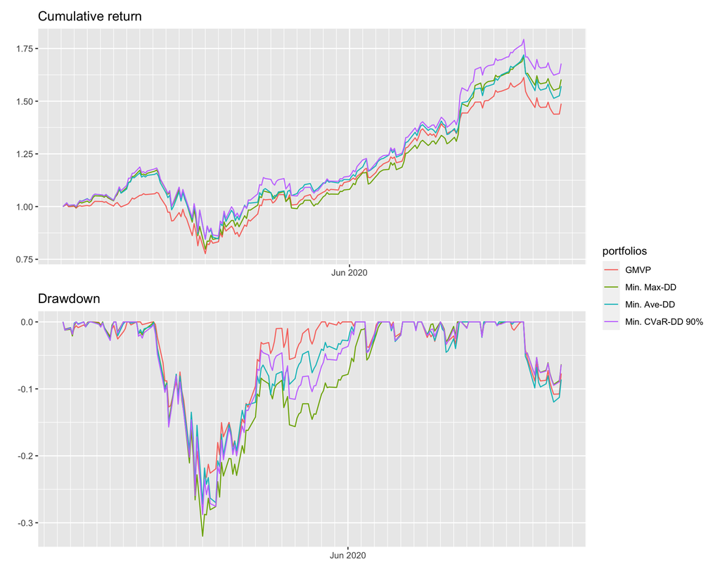

```r
p1 <- backtestChartCumReturn(bt) +
  scale_x_date(date_breaks = "6 months", date_labels = "%b %Y", date_minor_breaks = "1 week") +
  theme(legend.title = element_text()) + labs(color = "portfolios", linetype = "portfolios") +
  ggtitle("Cumulative return")

p2 <- backtestChartDrawdown(bt) +
  scale_x_date(date_breaks = "6 months", date_labels = "%b %Y", date_minor_breaks = "1 week") +
  theme(legend.title = element_text()) + labs(color = "portfolios", linetype = "portfolios") +
  ggtitle("Drawdown")

p1 / p2 + plot_layout(guides = "collect")
```

## Multiple backtests

Backtest performance of drawdown portfolios ($N=10$) over 50 datasets:

```r
library(pob)

# resample data
set.seed(42)
stock_prices_resampled <- financialDataResample(list("prices" = SP500_2015to2020$stocks),
                                                num_datasets = 50, N_sample = 10, T_sample = 252*2)
```

```
50 datasets resampled (with N = 10 instruments and length T = 504) from the original data between 2015-01-05 and 2020-09-22.
```

```r
# perform multiple backtest on the resampled data
bt <- portfolioBacktest(list("GMVP"             = GMVP,
                             "Min. Max-DD"      = MaxDD,
                             "Min. Ave-DD"      = AveDD,
                             "Min. CVaR-DD 90%" = CVaRDD_alpha90,
                             "Min. CVaR-DD 95%" = CVaRDD_alpha95,
                             "Min. CVaR-DD 99%" = CVaRDD_alpha99),
                        dataset_list = stock_prices_resampled,
                        lookback = 12*21, optimize_every = 21, rebalance_every = 1,
                        paral_datasets = 6, show_progress_bar = TRUE)
```

```
Backtesting 6 portfolios over 50 datasets (periodicity = daily data)...
```

```
  Backtesting function "GMVP           " (1/6)
```

```
  Backtesting function "Min. Max-DD    " (2/6)
```

```
  Backtesting function "Min. Ave-DD    " (3/6)
```

```
  Backtesting function "Min. CVaR-DD 90%" (4/6)
```

```
  Backtesting function "Min. CVaR-DD 95%" (5/6)
```

```
  Backtesting function "Min. CVaR-DD 99%" (6/6)
```

```r
listPortfoliosWithFailures(bt)

bt_summary_median <- backtestSummary(bt)
summaryTable(bt_summary_median, type = "kable", measures = c("Sharpe ratio", "CVaR", "max drawdown", "cpu time"))
```

Performance table

| Portfolio | Sharpe ratio | max drawdown | cpu time |
| --- | --- | --- | --- |
| GMVP | 0.99 | 12% | 0.14 |
| Min. Max-DD | 0.96 | 13% | 0.17 |
| Min. Ave-DD | 0.98 | 12% | 0.19 |
| Min. CVaR-DD 90% | 1.00 | 12% | 0.26 |
| Min. CVaR-DD 95% | 0.88 | 12% | 0.26 |
| Min. CVaR-DD 99% | 1.01 | 12% | 0.26 |

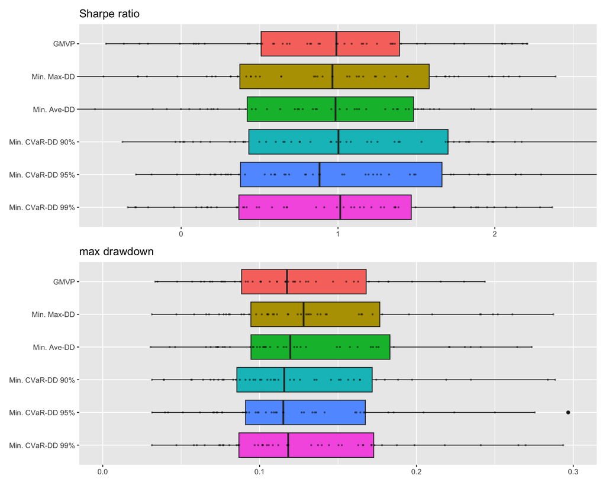

```r
p1 <- backtestBoxPlot(bt, "Sharpe ratio") + coord_flip(ylim = c(-0.5, 2.5))
p2 <- backtestBoxPlot(bt, "max drawdown") + coord_flip(ylim = c(0, 0.3))
p1 / p2
```